# Prediction Assignment

Youngkeun Yoon

2018-6-24

## Overview

This project is to predict behavioral classes of individuals based on the data collected from their wearable devices. Although many features were introduced in the original data, I had to remove some of them since there were no valuable information in them. Also, I conducted imputation for NAs in the remaining variables. Then, I utilized the Caret package to create Random Forest, LDA, KNN models with cross validation. Finally, I validated those models and selected Random Forest based on confusion matrix results.

## Data Loading & Preprocessing

##### Below codes are for downloading and loading the csv file on R.

```r
url_traindata="https://d396qusza40orc.cloudfront.net/predmachlearn/pml-training.csv"
url_testdata="https://d396qusza40orc.cloudfront.net/predmachlearn/pml-testing.csv"
download.file(url_traindata,destfile="training_data.csv")
download.file(url_testdata,destfile="testing_data.csv")
data <- read.csv("training_data.csv")
```

##### I set the seed for reproducibility. Also, I loaded all the packages that I will use.

```r
set.seed(123)
library(caret)
library(nnet)
library(DMwR)
```

##### First, I found that there are multiple variables which contain mostly NAs. So I excluded those variables. Second, I discovered that first 6 variables is irrelevant to behaviors of individuals so I also excluded them. Third, I found that some variables contained NAs. However, these NAs may get in the way when I start modelling so I imputed them. Finally, I split the data to training data and validation data so that I can choose the best model before actual application to test data.

```r
data2 <- data
removevarind <-nearZeroVar(data2)
data2 <- data2[, -removevarind]
data2 <- data2[, -(1:6)]
data2 <- centralImputation(data2)
idx <- createDataPartition(data2$roll_belt, p=.8)
traindata<- data2[idx$Resample1, ]
validationdata <- data2[-idx$Resample1, ]
```

## Modelling

##### I used caret package to conduct cross validation for each Random Forest, LDA and KNN methods.

```r
rfmodel <- train(classe~., data=traindata, method='rf', trControl=trainControl(method="CV", number=3))
ldamodel <- train(classe~., data=traindata, method="lda2", trControl=trainControl(method="CV", number=3))
```

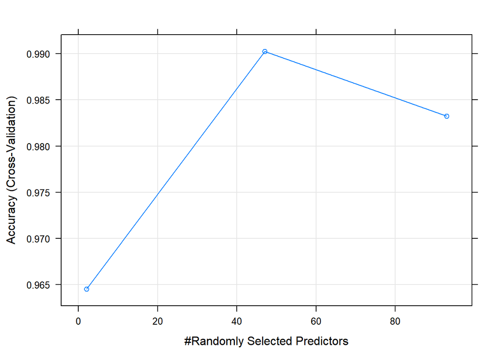

```r
knnmodel <- train(classe~., data=traindata, method="kknn", trControl=trainControl(method="CV", number=3))
plot(rfmodel)
```

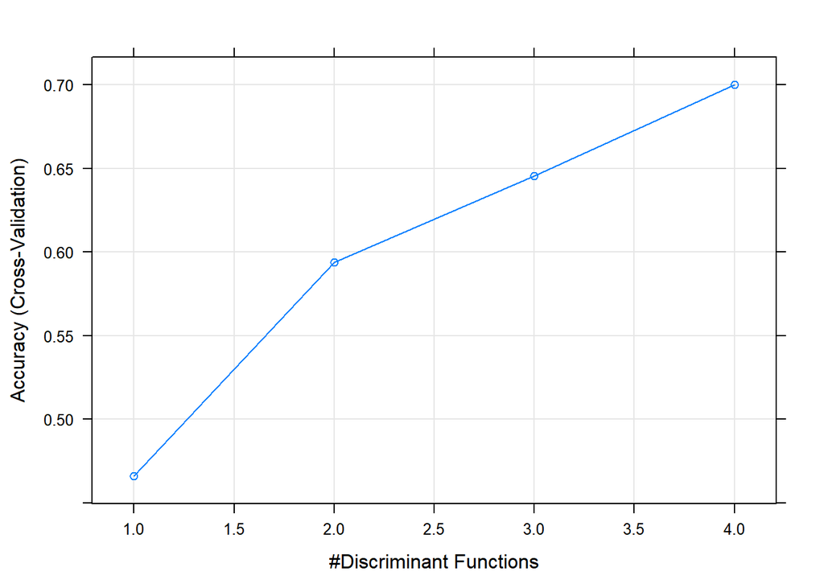

```r
plot(ldamodel)
```

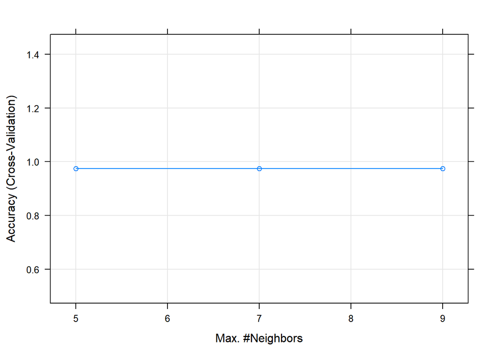

```r
plot(knnmodel)
```

## Selecting Best Model

##### I applied each models to the validation data and checked confusion matrix

### Random Forest

##### Random Forest model had the highest accuracy so I determined that it is the best model.

```r
rfvalid <- predict(rfmodel, validationdata)
rfcfmatrix <- confusionMatrix(validationdata$classe, rfvalid)
rfcfmatrix
```

```
## Confusion Matrix and Statistics
##
##           Reference
## Prediction    A    B    C    D    E
##          A 1151    0    0    0    0
##          B    5  735    3    0    0
##          C    0    2  663    2    0
##          D    0    0    6  649    0
##          E    0    0    0    2  705
##
## Overall Statistics
##
##                Accuracy : 0.9949
##                  95% CI : (0.9921, 0.9969)
##     No Information Rate : 0.2947
##     P-Value [Acc > NIR] : < 2.2e-16
##
##                   Kappa : 0.9935
##  Mcnemar's Test P-Value : NA
##
## Statistics by Class:
##
##                      Class: A Class: B Class: C Class: D Class: E
## Sensitivity            0.9957   0.9973   0.9866   0.9939   1.0000
## Specificity            1.0000   0.9975   0.9988   0.9982   0.9994
## Pos Pred Value         1.0000   0.9892   0.9940   0.9908   0.9972
## Neg Pred Value         0.9982   0.9994   0.9972   0.9988   1.0000
## Prevalence             0.2947   0.1879   0.1713   0.1665   0.1797
## Detection Rate         0.2934   0.1874   0.1690   0.1654   0.1797
## Detection Prevalence   0.2934   0.1894   0.1700   0.1670   0.1802
## Balanced Accuracy      0.9978   0.9974   0.9927   0.9960   0.9997
```

### LDA

##### LDA model had low accuracy so I discarded it.

```r
ldavalid <- predict(ldamodel, validationdata)
ldacfmatrix <- confusionMatrix(validationdata$classe, ldavalid)
ldacfmatrix
```

```
## Confusion Matrix and Statistics
##
##           Reference
## Prediction   A   B   C   D   E
##          A 927  21 110  87   6
##          B 107 473  91  32  40
##          C  71  59 444  83  10
##          D  38  24  76 498  19
##          E  25 128  69  77 408
##
## Overall Statistics
##
##                Accuracy : 0.701
##                  95% CI : (0.6864, 0.7153)
##     No Information Rate : 0.2977
##     P-Value [Acc > NIR] : < 2.2e-16
##
##                   Kappa : 0.6211
##  Mcnemar's Test P-Value : < 2.2e-16
##
## Statistics by Class:
##
##                      Class: A Class: B Class: C Class: D Class: E
## Sensitivity            0.7937   0.6709   0.5620   0.6409   0.8447
## Specificity            0.9187   0.9161   0.9288   0.9501   0.9131
## Pos Pred Value         0.8054   0.6366   0.6657   0.7603   0.5771
## Neg Pred Value         0.9131   0.9270   0.8937   0.9146   0.9767
## Prevalence             0.2977   0.1797   0.2014   0.1981   0.1231
## Detection Rate         0.2363   0.1206   0.1132   0.1269   0.1040
## Detection Prevalence   0.2934   0.1894   0.1700   0.1670   0.1802
## Balanced Accuracy      0.8562   0.7935   0.7454   0.7955   0.8789
```

### KNN

##### Although KNN model had high accuracy, Random Forest model showed better performance.

```r
knnvalid <- predict(knnmodel, validationdata)
knncfmatrix <- confusionMatrix(validationdata$classe, knnvalid)
knncfmatrix
```

```
## Confusion Matrix and Statistics
##
##           Reference
## Prediction    A    B    C    D    E
##          A 1141    3    7    0    0
##          B    3  738    2    0    0
##          C    2    1  658    5    1
##          D    2    0    5  648    0
##          E    0    4    0    2  701
##
## Overall Statistics
##
##                Accuracy : 0.9906
##                  95% CI : (0.987, 0.9934)
##     No Information Rate : 0.2926
##     P-Value [Acc > NIR] : < 2.2e-16
##
##                   Kappa : 0.988
##  Mcnemar's Test P-Value : NA
##
## Statistics by Class:
##
##                      Class: A Class: B Class: C Class: D Class: E
## Sensitivity            0.9939   0.9893   0.9792   0.9893   0.9986
## Specificity            0.9964   0.9984   0.9972   0.9979   0.9981
## Pos Pred Value         0.9913   0.9933   0.9865   0.9893   0.9915
## Neg Pred Value         0.9975   0.9975   0.9957   0.9979   0.9997
## Prevalence             0.2926   0.1902   0.1713   0.1670   0.1789
## Detection Rate         0.2908   0.1881   0.1677   0.1652   0.1787
## Detection Prevalence   0.2934   0.1894   0.1700   0.1670   0.1802
## Balanced Accuracy      0.9951   0.9939   0.9882   0.9936   0.9984
```